# Exam 1 - Units, Vectors, and Kinematics

**Date:** / /

**Class Number:** PHYS 1061 H002 **Instructor:** Michael Haas

**Name:**

Please read and follow all instructions carefully. Use the back of the sheet if necessary. Mars has $g=3.72 \frac{\mathrm{m}}{\mathrm{s}^{2}}$.

Score: / 42 + Bonus: / 6 = Total: / 42 || Final: % -> [A, B, C, D, F]

Problem #1 (3 points)

A truck with mass $12.3 \mathrm{Mg}$ collides with a bug with mass $0.432 \mathrm{g}$. How does the magnitude of the bug's force on the truck compare to the magnitude of the truck's force on the bug?

1. The bug's force on the truck is greater than the truck's force on the bug.
2. The truck's force on the bug is greater than the bug's force on the truck.
3. The two forces are equal in magnitude.
4. It is impossible to determine without more information.

Problem #2 (3 points)

A $10.0 \mathrm{kg}$ box is at rest on an inclined ramp. Which of the following correctly describes the magnitude of force due to static friction?

1. $|\vec{f_s}|=|\vec{W}|$
2. $|\vec{f_s}|=|\vec{N}|$
3. $|\vec{f_s}|=|\vec{W_\bot}|$
4. $|\vec{f_s}|=|\vec{W_\parallel}|$
5. $|\vec{f_s}|=0$

Problem #3 (3 points)

A baby is pushing on a walker with a force of $10.0 \mathrm{N}$ at an angle of $30.0 ^\circ$ above the horizontal. What is the magnitude of the horizontal component of the force he is applying?

1. $ F_x = 10.0 \mathrm{N} \cos(30.0 ^\circ)$
2. $F_x = 10.0 \mathrm{N} \sin(30.0 ^\circ)$
3. $F_x = 10.0 \mathrm{N}$
4. $F_x = 10.0 \mathrm{N} \tan(30.0 ^\circ)$

Problem #4 (3 points)

Which of the following is not one of Newton's laws of motion?

1. $\vec{F} = m \vec{a}$
2. When in equilibrium: $\vec{F}_{\mathrm{net}} = 0$
3. $f=\mu N$
4. $\vec{F}_{\mathrm{AB}} = -\vec{F}_{\mathrm{BA}}$

Problem #5 (3 points)

Arthur Dent is in an elevator on the planet Squornshellous Zeta where the gravitational acceleration is $g_{\mathrm{Squornshellous}}=5.70 \frac{\mathrm{m}}{\mathrm{s}^{2}}$. The elevator is accelerating upwards at $2.00 \frac{\mathrm{m}}{\mathrm{s}^{2}}$. What is the magnitude of the normal force on Arthur if his mass is $70.0 \mathrm{kg}$?

1. $N = m g = 399. \frac{\mathrm{kg} \cdot \mathrm{m}}{\mathrm{s}^{2}}$
2. $N = m g + m a = 539. \frac{\mathrm{kg} \cdot \mathrm{m}}{\mathrm{s}^{2}}$
3. $N = m g - m a = 259. \frac{\mathrm{kg} \cdot \mathrm{m}}{\mathrm{s}^{2}}$
4. $N = m a = 140. \frac{\mathrm{kg} \cdot \mathrm{m}}{\mathrm{s}^{2}}$

Problem #6 (3 points)

Boudreaux is moving a box along a horizontal surface, but he can't decide if he should push the box by exerting force $\vec{F_1}$, or pull the box by exerting force $\vec{F_2}$. Assuming both forces are at the same angle from the horizontal, which one gives the least friction between the box and the surface?

1. $\vec{F_1}$
2. $\vec{F_2}$
3. Both forces result in the same friction.
4. It is impossible to determine without more information.

Problem #7 (3 points)

An object is hanging by a string from the ceiling of an elevator. The elevator is slowing down while moving upward. What can be said about the magnitude of the tension in the string?

1. The magnitude of the tension is less than the magnitude of the resting weight of the object.
2. The tension in the string cannot be determined without knowing the speed of the elevator.
3. The magnitude of the tension is greater than the magnitude of the resting weight of the object.
4. The tension in the string is zero.
5. The magnitude of the tension in the string is equal to the magnitude of the resting weight of the object.

Bonus #8 (3 points) Severus Snape, $3.20e+05 $, 1, 1, 2, 3, 5 or 0, 1, 1, 2, 3

Bonus est omnis divisa in partes tres: Who is the half blood prince? How many centimeters is $3.20 \mathrm{km}$? Write out the first 5 numbers in the Fibonacci sequence.

Problem #9 (9 points)

Baby Godric (who currently has a mass of $9.98 \mathrm{kg}$) is being held up by his mom as in the picture. Treat each of his arms as ideal tension ropes.

Question #1 (3 points)

Draw a free body diagram for Godric showing all forces acting on him.

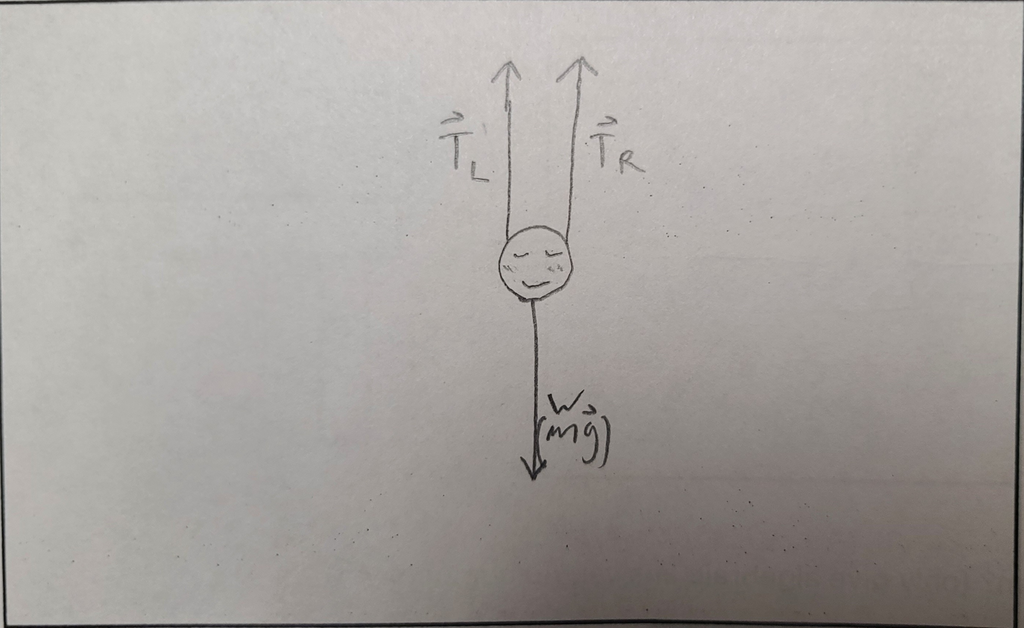

[figure not shown]

Question #2 (3 points)

What is the tension in his right arm?

$T_\mathrm{L} + T_\mathrm{R} = m g = 9.98 \mathrm{kg} * -9.80 \frac{\mathrm{m}}{\mathrm{s}^{2}}$

$T_\mathrm{L} = -97.8 \frac{\mathrm{kg} \cdot \mathrm{m}}{\mathrm{s}^{2}} - T_\mathrm{R}$

Notice: $T_\mathrm{L} = T_\mathrm{R}$

$T_\mathrm{L} = T_\mathrm{R} = \frac{m g}{2} = -48.9 \frac{\mathrm{kg} \cdot \mathrm{m}}{\mathrm{s}^{2}}$

Question #3 (3 points)

What would the tension in the right arm be if they were in an elevator accelerating upward at $2.00 \frac{\mathrm{m}}{\mathrm{s}^{2}}$?

$T_\mathrm{L} + T_\mathrm{R} = m (g + a) = 9.98 \mathrm{kg} * (-9.80 \frac{\mathrm{m}}{\mathrm{s}^{2}} + 2.00 \frac{\mathrm{m}}{\mathrm{s}^{2}})$

$T_\mathrm{L} = -77.8 \frac{\mathrm{kg} \cdot \mathrm{m}}{\mathrm{s}^{2}} - T_\mathrm{R}$

Notice: $T_\mathrm{L} = T_\mathrm{R}$

Problem #11 (12 points)

Two boxes are connected by a string (assume massless, frictionless string that never breaks) over a pulley. Box 1 has mass $10.0 \mathrm{kg}$ and is on a table where the coefficient of kinetic friction is $\mu_k=0.200 $. Box 2 has mass $5.00 \mathrm{kg}$ and is hanging from the string. The system is in motion (meaning $v_{x_{\mathrm{Box1}}} \ne 0$).

Question #1 (3 points)

Draw a free body diagram for each box showing all forces acting on it.

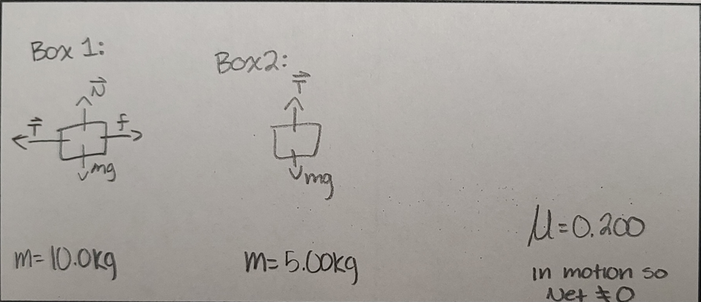

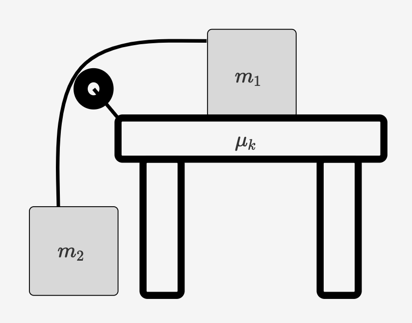

Question #2 (3 points)

What is the acceleration of the system? (only give algebraic answer, no numbers yet)

$\sum_{\mathrm{ext}}^{}{F_x} = m_1 a_x = T_1 - f_k$ and $\sum_{\mathrm{ext}}^{}{F_y} = m_2 a_y = m_2 g - T_2$

$a_x = a_y = a$ and $T_1 = T_2 \implies T = f_k + m_1a = T = m_2 g - m_2 a$

$m_1 a + m_2 a = m_2 g - f_k \implies a = \frac{m_2 g - f_k}{m_1 + m_2}$

Question #3 (3 points)

What is the acceleration of the system? (give a number with units, 3 significant figures)

$a = \frac{m_2 g - f_k}{m_1 + m_2}$, $f_k=\mu_k N$, $N=m_1 g$, $f_k=\mu_k m_1 g$

$a = \frac{ (5.00 \mathrm{kg}) (-9.80 \frac{\mathrm{m}}{\mathrm{s}^{2}}) - (0.200 ) (10.0 \mathrm{kg}) (-9.80 \frac{\mathrm{m}}{\mathrm{s}^{2}})}{10.0 \mathrm{kg} + 5.00 \mathrm{kg}}$

$a = -1.96 \frac{\mathrm{m}}{\mathrm{s}^{2}}$

Question #4 (3 points)

What is the tension in the string?

$T = f_k + m_1 a = \mu_k m_1 g + m_1 a = (0.200 ) (10.0 \mathrm{kg}) (-9.80 \frac{\mathrm{m}}{\mathrm{s}^{2}}) + (10.0 \mathrm{kg}) (-1.96 \frac{\mathrm{m}}{\mathrm{s}^{2}})$

$T=-39.2 \frac{\mathrm{kg} \cdot \mathrm{m}}{\mathrm{s}^{2}}$

Tension in in an ideal string is always positive, so $T_\mathrm{string} = 39.2 \frac{\mathrm{kg} \cdot \mathrm{m}}{\mathrm{s}^{2}}$